# RepData_PeerAssessment1

SaraGordon

5/24/2021

## Loading and preprocessing the data

Show any code that is needed to:  
- Load the data - Process/transform the data (if necessary)

```r
if (!file.exists("data")) {dir.create("data")}
fileURL <- "https://d396qusza40orc.cloudfront.net/repdata%2Fdata%2Factivity.zip"
download.file(fileURL, destfile = "./data/Factivity.zip", method = "curl")
unzip("./data/Factivity.zip", exdir = "./data")

list.files("./data")
```

```
## [1] "activity.csv"  "Factivity.zip"
```

```r
ActData <- read.csv("./data/activity.csv", sep = ",", header=TRUE)

##Change the date column to date class
ActData$date <- as.Date(ActData$date)
str(ActData)
```

```
## 'data.frame':    17568 obs. of  3 variables:
##  $ steps   : int  NA NA NA NA NA NA NA NA NA NA ...
##  $ date    : Date, format: "2012-10-01" "2012-10-01" ...
##  $ interval: int  0 5 10 15 20 25 30 35 40 45 ...
```

## What is total number of steps taken per day?

1. Calculate the total number of steps per day

```r
library(dplyr)
stepSum <- summarize(group_by(ActData, date), stepTotal=sum(steps))
```

2. Make a histogram of the total number of steps per day

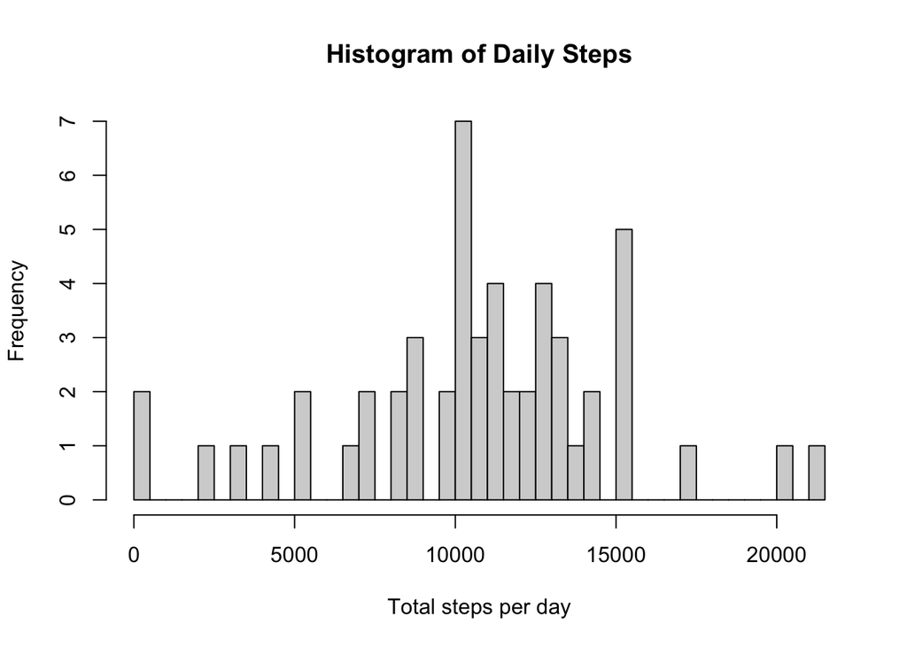

```r
hist(stepSum$stepTotal, breaks = 60, main = "Histogram of Daily Steps", xlab = "Total steps per day")
```

```r
stepMean <- mean(stepSum$stepTotal, na.rm = TRUE)
stepMedian <- median(stepSum$stepTotal, na.rm = TRUE)
```

## What is the average daily activity pattern?

1. Make a time series plot of the 5-minute interval (x-axis) and the average number of steps taken, averaged across all days (y-axis)

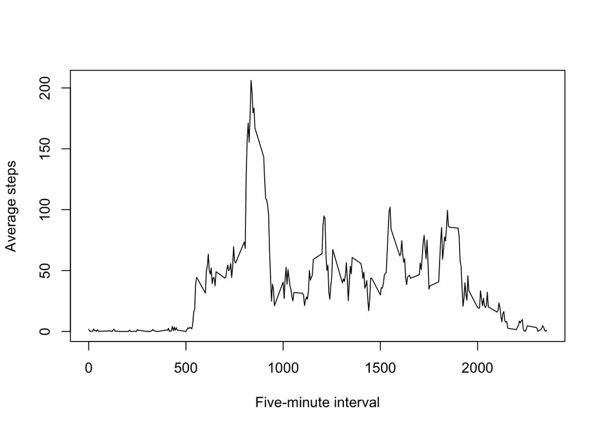

```r
dailySteps <- summarize(group_by(ActData, interval), avgSteps=mean(steps, na.rm=TRUE))

with(dailySteps, plot(interval, avgSteps, type = "l", ylab = "Average steps", xlab = "Five-minute interval"))
```

2. Which 5-minute interval, on average across all the days in the dataset, contains the maximum number of steps?

```r
which.max(dailySteps$avgSteps)
```

```
## [1] 104
```

```r
busiest <- dailySteps[104,]
intName <- busiest$interval
intAvg <- busiest$avgSteps
```

The interval with the highest average number of steps is 835, with 206.1698113 steps.

## Imputing missing values

1. Calculate and report the total number of missing values in the dataset.

```r
naSum <- sum(is.na(ActData))
naSum
```

```
## [1] 2304
```

2. Devise a strategy for filling in all of the missing values in the dataset.
3. Create a new dataset that is equal to the original but with the missing data filled in.

```r
library(Hmisc)
NAData <- ActData

#Impute using mode function
ImpData <- NAData %>%
  group_by(interval) %>%
  mutate(steps = impute(steps, median))

#Detach Hmisc so it doesn't interfere with dplyr
detach("package:Hmisc", unload = TRUE)
```

4a. Make a histogram of the total number of steps taken each day.

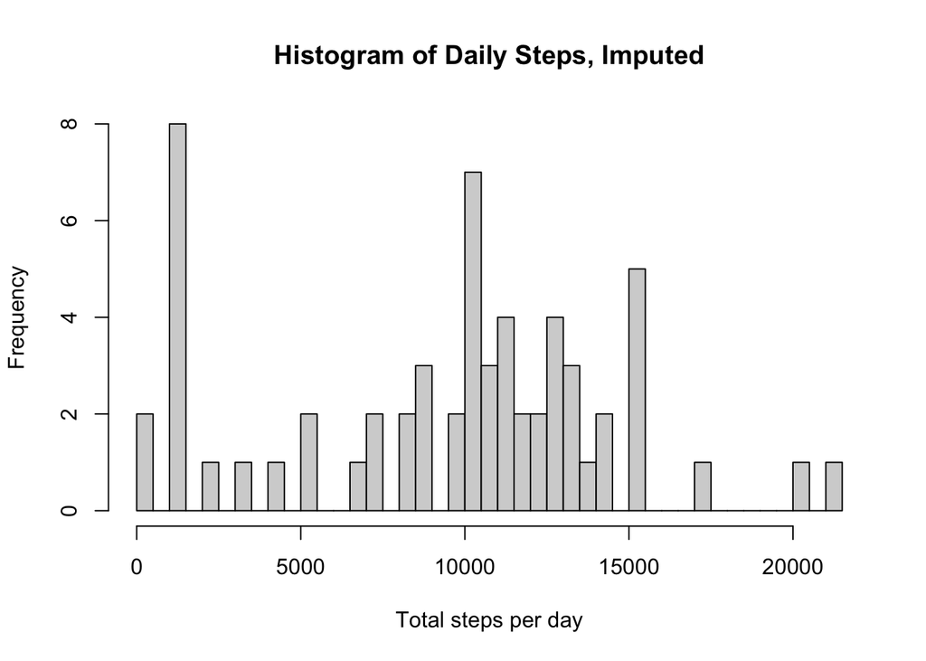

```r
ImpSum <- summarize(group_by(ImpData, date), stepTotal=sum(steps))

hist(ImpSum$stepTotal, breaks = 60, main = "Histogram of Daily Steps, Imputed", xlab = "Total steps per day")
```

4b. Calculate and report the mean and median total number of steps taken per day.

```r
impMean <- mean(ImpSum$stepTotal)
impMedian <- median(ImpSum$stepTotal)
```

The mean of the total number of imputed steps is 9503.8688525.  
The median of the total number of imputed steps is 10395.

4c. Do these values differ from the estimates from the first part of the assignment?

```r
if (impMean == stepMean) {
  print("The mean number of steps from the imputed and not-imputed datasets is the same.")
} else if (impMean < stepMean) {
  print("The imputed mean is less than the not-imputed mean.")
} else if (impMean > stepMean) {
  print("The imputed mean is greater than the not-imputed mean.")
}
```

```
## [1] "The imputed mean is less than the not-imputed mean."
```

```r
if (impMedian == stepMedian) {
  print("The median number of steps from the imputed and not-imputed datasets is the same.")
} else if (impMedian < stepMedian) {
  print("The imputed median is less than the not-imputed median.")
} else if (impMedian > stepMedian) {
  print("The imputed median is greater than the not-imputed median.")
}
```

```
## [1] "The imputed median is less than the not-imputed median."
```

4d. What is the impact of imputing missing data on the estimates of the total daily number of steps?

```r
ActStepSum <- sum(ActData$steps, na.rm = TRUE)
ImpStepSum <- sum(ImpData$steps)

if (ActStepSum == ImpStepSum) {
  print("The total number of steps from the imputed and not-imputed datasets is the same.")
} else if (ActStepSum < ImpStepSum) {
  print("The imputed step total is less than the not-imputed step total.")
} else if (ActStepSum > ImpStepSum) {
  print("The imputed step total is greater than the not-imputed step total.")
}
```

[output not shown]

## Are there differences in activity patterns between weekdays and weekends?

1. Create a new factor variable in the dataset with two levels – “weekday” and “weekend” – indicating whether a given date is a weekday or weekend day.

```r
ImpData$dayName <- weekdays(ImpData$date)

weekdata <- subset(ImpData, dayName != c("Saturday", "Sunday"))
weekenddata <- subset(ImpData, dayName == c("Saturday", "Sunday"))

weekdata$dayType <- "weekday"
weekenddata$dayType <- "weekend"

ImpData2 <- rbind(weekdata, weekenddata)

ImpData2$dayType <- as.factor(ImpData2$dayType)
```

2. Make a panel plot containing a time series plot of the 5-minute interval (x-axis) and the average number of steps taken, averaged across all weekday days or weekend days (y-axis).

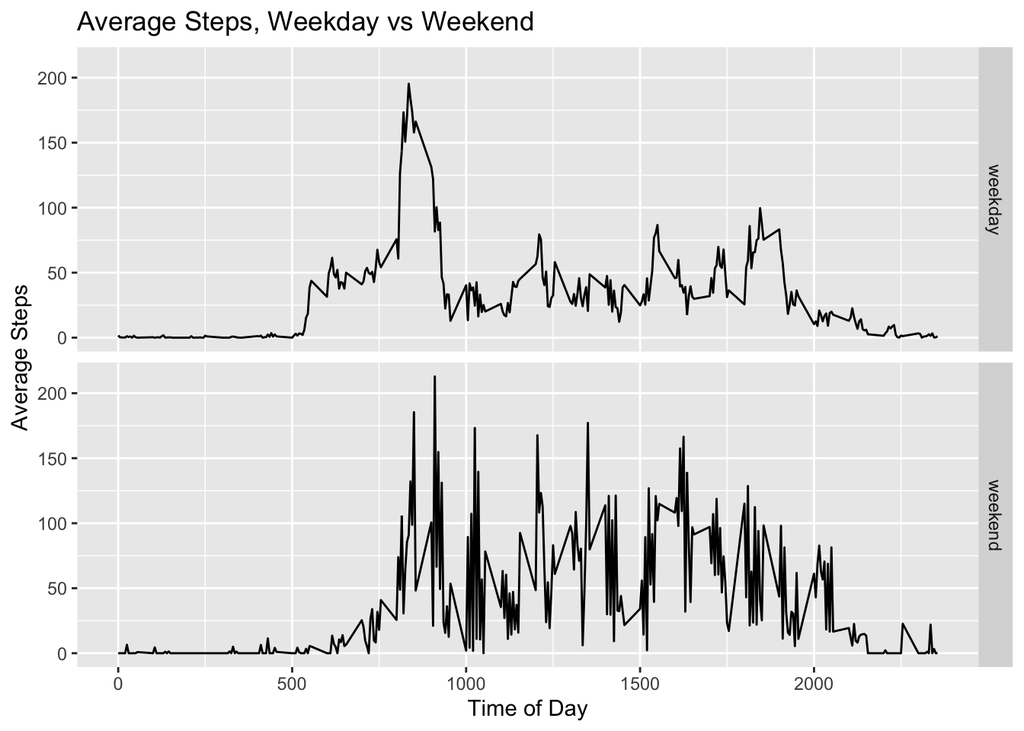

```r
library(ggplot2)
weekSteps <- summarize(group_by(ImpData2, interval, dayType), steps=mean(steps))
ggplot(data=weekSteps, aes(x=interval, y=steps)) + facet_grid(dayType~.) + geom_line() + labs(title = "Average Steps, Weekday vs Weekend") + labs(x = "Time of Day") + labs(y = "Average Steps")
```